# MATH2319 Machine Learning

## Semester 1, 2020

1. I hereby agree to follow any and all assignment rules and procedures as stated in Canvas for this course, MATH2319.
2. In particular, I solemnly swear that I will not discuss/ have not discussed my assignment solutions with anyone in any way and the solutions I am submitting are my own personal work.

**`Group : 10`**

1. Sridevi Pamarthi (s3778317)
2. Divya Ulaganathan (s3759465)

# Prediction of Diabetes with classification models

## Objective

The aim of this project is to predict whether an individual tests positive or negative for diabetes using [Pima Indians Diabetes Database](https://www.openml.org/d/37) from OpenML. By fitting and comparing five different binary classifiers to the database, the identified best classifier will be proposed for prediction.

## Methodology

### Data Description

The Pima Indians Diabetes dataset has diagnostic information of 768 female patients who are at least 21 years old and of Pima Indian heritage. It has 8 predictor variables and 1 target feature which has two classes defined as `tested_positive` and `tested_negative` respectively. There are no missing values.

The dataset consists of following features :

- **preg** : Number of times pregnant
- **plas** : Plasma glucose concentration a 2 hours in an oral glucose tolerance test
- **pres** : Diastolic blood pressure (mm Hg)
- **skin** : Triceps skin fold thickness (mm)
- **insu** : 2-Hour serum insulin (mu U/ml)
- **mass** : Body mass index (weight in kg/(height in m)^2)
- **pedi** : Diabetes pedigree function(a function which scores likelihood of diabetes based on family history)
- **age** : Age (years)
- **class**: Test result positive or negative

### Data Retrieval

The diabetes dataset has been loaded into `diabetes` dataframe using pandas in the following step.

```python
import warnings
import pandas as pd
import numpy as np
warnings.filterwarnings("ignore")
pd.set_option('display.max_columns', None)


featureNames = ['preg','plas','pres','skin','insu','mass','pedi','age','class']

diabetes = pd.read_csv('s3778317_s3759465_Data.csv',sep=',', decimal='.',skiprows=1,names=featureNames)
```

```python
diabetes.shape
```

```
(768, 9)
```

```python
# Setting a seed value
seed_value = 999
# Initialise `PYTHONHASHSEED` environment variable
import os
os.environ['PYTHONHASHSEED']=str(seed_value)
# Python's  pseudo-random generator
import random
random.seed(seed_value)
# 3. Initialise Numpy's pseudo-random generator
np.random.seed(seed_value)
```

```python
diabetes.sample(n=10)
```

|  | preg | plas | pres | skin | insu | mass | pedi | age | class |
| --- | --- | --- | --- | --- | --- | --- | --- | --- | --- |
| 441 | 2 | 83 | 66 | 23 | 50 | 32.2 | 0.497 | 22 | tested_negative |
| 57 | 0 | 100 | 88 | 60 | 110 | 46.8 | 0.962 | 31 | tested_negative |
| 68 | 1 | 95 | 66 | 13 | 38 | 19.6 | 0.334 | 25 | tested_negative |
| 95 | 6 | 144 | 72 | 27 | 228 | 33.9 | 0.255 | 40 | tested_negative |
| 411 | 1 | 112 | 72 | 30 | 176 | 34.4 | 0.528 | 25 | tested_negative |
| 192 | 7 | 159 | 66 | 0 | 0 | 30.4 | 0.383 | 36 | tested_positive |
| 352 | 3 | 61 | 82 | 28 | 0 | 34.4 | 0.243 | 46 | tested_negative |
| 400 | 4 | 95 | 64 | 0 | 0 | 32.0 | 0.161 | 31 | tested_positive |
| 677 | 0 | 93 | 60 | 0 | 0 | 35.3 | 0.263 | 25 | tested_negative |
| 376 | 0 | 98 | 82 | 15 | 84 | 25.2 | 0.299 | 22 | tested_negative |

Dataset has been successfully loaded to a dataframe and obeserved there are 768 rows and 9 columns

### Data Preprocessing

In this section we have dealt with the following

Datatypes of feature in this data are as follows

```python
diabetes.dtypes
```

```
preg       int64
plas       int64
pres       int64
skin       int64
insu       int64
mass     float64
pedi     float64
age        int64
class     object
dtype: object
```

Descriptive statistics of features are as follows

```python
diabetes.describe(include = np.number).round(2)
```

|  | preg | plas | pres | skin | insu | mass | pedi | age |
| --- | --- | --- | --- | --- | --- | --- | --- | --- |
| count | 768.00 | 768.00 | 768.00 | 768.00 | 768.00 | 768.00 | 768.00 | 768.00 |
| mean | 3.85 | 120.89 | 69.11 | 20.54 | 79.80 | 31.99 | 0.47 | 33.24 |
| std | 3.37 | 31.97 | 19.36 | 15.95 | 115.24 | 7.88 | 0.33 | 11.76 |
| min | 0.00 | 0.00 | 0.00 | 0.00 | 0.00 | 0.00 | 0.08 | 21.00 |
| 25% | 1.00 | 99.00 | 62.00 | 0.00 | 0.00 | 27.30 | 0.24 | 24.00 |
| 50% | 3.00 | 117.00 | 72.00 | 23.00 | 30.50 | 32.00 | 0.37 | 29.00 |
| 75% | 6.00 | 140.25 | 80.00 | 32.00 | 127.25 | 36.60 | 0.63 | 41.00 |
| max | 17.00 | 199.00 | 122.00 | 99.00 | 846.00 | 67.10 | 2.42 | 81.00 |

From above descriptive statistics features like plas, mass, pres etc., has 0 as minimum value which is not right. Although preg feature also has minimum value as 0, it is still valid as the patient might not have been pregnant before. Hence, we treat 0 value on rest of them as unknown values and replace them with median values in the following steps.

```python
# Copy original dataset to diabetes_df
diabetes_df = diabetes.copy()
# Replacing 0 with median
diabetes_df['plas'].replace(0,diabetes_df['plas'].median(),inplace=True)
diabetes_df['pres'].replace(0,diabetes_df['pres'].median(),inplace=True)
diabetes_df['skin'].replace(0,diabetes_df['skin'].median(),inplace=True)
diabetes_df['insu'].replace(0,diabetes_df['insu'].median(),inplace=True)
diabetes_df['mass'].replace(0,diabetes_df['mass'].median(),inplace=True)
diabetes_df.describe(include = np.number).round(2)
```

|  | preg | plas | pres | skin | insu | mass | pedi | age |
| --- | --- | --- | --- | --- | --- | --- | --- | --- |
| count | 768.00 | 768.00 | 768.00 | 768.00 | 768.00 | 768.00 | 768.00 | 768.00 |
| mean | 3.85 | 121.66 | 72.39 | 27.33 | 94.65 | 32.45 | 0.47 | 33.24 |
| std | 3.37 | 30.44 | 12.10 | 9.23 | 105.55 | 6.88 | 0.33 | 11.76 |
| min | 0.00 | 44.00 | 24.00 | 7.00 | 14.00 | 18.20 | 0.08 | 21.00 |
| 25% | 1.00 | 99.75 | 64.00 | 23.00 | 30.50 | 27.50 | 0.24 | 24.00 |
| 50% | 3.00 | 117.00 | 72.00 | 23.00 | 31.25 | 32.00 | 0.37 | 29.00 |
| 75% | 6.00 | 140.25 | 80.00 | 32.00 | 127.25 | 36.60 | 0.63 | 41.00 |
| max | 17.00 | 199.00 | 122.00 | 99.00 | 846.00 | 67.10 | 2.42 | 81.00 |

The unknown values(0) are successfully replaced with median.

#### Removing redundant value in `class` feature

The 'class' feature has redundant value `tested_` in it. Hence, we remove it in upcoming steps.

```python
diabetes_df['class'].head(5)
```

```
0    tested_positive
1    tested_negative
2    tested_positive
3    tested_negative
4    tested_positive
Name: class, dtype: object
```

```python
# remove 'tested_' string from class
diabetes_df['class']=diabetes_df['class'].apply(lambda x:(x.replace("tested_","")))
```

```python
diabetes_df['class'].value_counts()
```

```
negative    500
positive    268
Name: class, dtype: int64
```

#### Discretizing `age` Feature

Age feature has been discretized into 3 bins such as 'young','middle-aged','old' in the following steps

```python
#Discretizing age Feature
diabetes_df['age'] = pd.qcut(diabetes_df['age'], q=3,
                                     labels=['young','middle-aged','old'])
```

```python
diabetes_df['age'].value_counts()
```

```
young          267
old            254
middle-aged    247
Name: age, dtype: int64
```

#### Discretizing `mass` Feature

Mass feature has been discretized into 4 bins such as 'underweight', 'healthy', 'overweight' and 'obese' in the following step based on BMI ranges.

```python
#less than 18.5 , 18.5-25, 25-30 , above 30

bins = [0, 18.5, 25, 30, 70]
names = ['underweight', 'healthy', 'overweight', 'obese']

diabetes_df['mass'] = pd.cut(diabetes_df['mass'] , bins, labels=names)
diabetes_df['mass'].value_counts()
```

```
obese          476
overweight     180
healthy        108
underweight      4
Name: mass, dtype: int64
```

#### Integer Encoding

Features `age` and `mass` are re-encoded to integers as follows.

```python
# defining age and mass levels
diabetes_df_copy =diabetes_df.copy()
level_age = {'young': 1, 'middle-aged': 2, 'old': 3}
level_mass = {'underweight' : 1, 'healthy' : 2, 'overweight' : 3, 'obese' : 4}

# Encoding age and mass
diabetes_df_copy['age'] = diabetes_df['age'].replace(level_age)

diabetes_df_copy['mass'] = diabetes_df['mass'].replace(level_mass)

diabetes_df_copy.head(5)
```

|  | preg | plas | pres | skin | insu | mass | pedi | age | class |
| --- | --- | --- | --- | --- | --- | --- | --- | --- | --- |
| 0 | 6 | 148 | 72 | 35 | 30.5 | 4 | 0.627 | 3 | positive |
| 1 | 1 | 85 | 66 | 29 | 30.5 | 3 | 0.351 | 2 | negative |
| 2 | 8 | 183 | 64 | 23 | 30.5 | 2 | 0.672 | 2 | positive |
| 3 | 1 | 89 | 66 | 23 | 94.0 | 3 | 0.167 | 1 | negative |
| 4 | 0 | 137 | 40 | 35 | 168.0 | 4 | 2.288 | 2 | positive |

#### Target Encoding

In the following step `negative` in class variable is encoded as `0` and `positive` as `1`.

```python
# Encoding class feature
diabetes_df_copy['class'].replace('negative','0',inplace=True)
diabetes_df_copy['class'].replace('positive','1',inplace=True)
```

```python
diabetes_df['class'].value_counts()
```

```
negative    500
positive    268
Name: class, dtype: int64
```

In the following step, all features except for 'class' are added to Data and 'class' feature is added to Target.

```python
# Selecting Data and Target features
Data = diabetes_df_copy.drop(columns = 'class').values

Target = diabetes_df_copy['class'].values
```

#### Scaling of Features

We make a copy of the Data to keep track of column names and apply Min-Max scaling to the data.

```python
# Scaling function
from sklearn import preprocessing

Data_df = Data.copy()

Data_scaler = preprocessing.MinMaxScaler()
Data_scaler.fit(Data)
Data = Data_scaler.fit_transform(Data)
```

Data set is small we dont require sampling

## Data Exploration

### One variable plots

**Plot:1** In order to understand count of positive and negative diabetes observations, following pie chart has been plotted

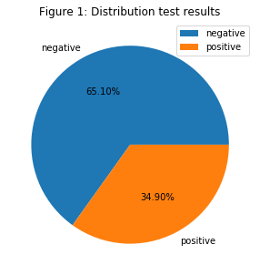

```python
# pie chart of class feature
import matplotlib.pyplot as plt
diabetes_df['class'].value_counts().plot(kind='pie',autopct='%.2f%%', figsize = (5,5))
plt.title("Figure 1: Distribution test results")
plt.ylabel("")
plt.legend()
plt.show()
```

From above pie chart there are 34.9% positive values and 65.10% negative values in Target feature `class`

**Plot:2** In order to understand counts of `mass` feature a bar plot is plotted

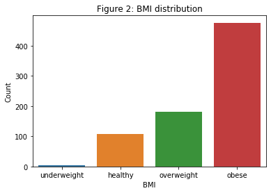

```python
# bar plot of mass feature
import seaborn as sns
sns.countplot(x= 'mass' ,data=diabetes_df)
plt.title("Figure 2: BMI distribution")
plt.xlabel("BMI")
plt.ylabel("Count")
plt.show()
```

From the above bar plot there are more observations with obese category in `mass` feature

**Plot3:** To understand counts of `age` feature

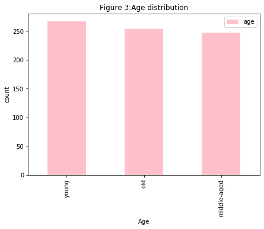

```python
# Bar plot of age feature
diabetes_df['age'].value_counts().plot(
    kind    = 'bar',
    title   = 'Figure 3:Age distribution',
    legend  = True,
    figsize = (7,5),
    color   = 'pink',fontsize=10
)
plt.ylabel('count')
plt.xlabel('Age')
plt.show()
```

Women of all age categories were equally distributed in the given sample.

### Two variable plots

**Plot1:** In order to understand which age group has more positive test results the following plot has been plottted

| class age | perc1 | perc0 |
| --- | --- | --- |
| young | 0.169 | 0.831 |
| middle-aged | 0.389 | 0.611 |
| old | 0.500 | 0.500 |

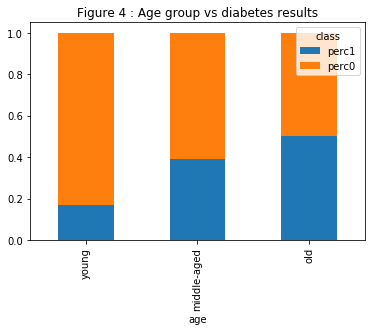

```python
#correlation between Age and class
def corr_2_cols(Col1, Col2):
    res = diabetes_df.groupby([Col1, Col2]).size().unstack()
    res['perc1'] = (res[res.columns[1]]/(res[res.columns[0]] + res[res.columns[1]]))
    res['perc0'] = (res[res.columns[0]]/(res[res.columns[0]] + res[res.columns[1]]))
    del res[res.columns[1]]
    del res[res.columns[0]]
    return res

corr_2_cols('age', 'class').plot(stacked=True,kind="bar", title="Figure 4 : Age group vs diabetes results")
round(corr_2_cols('age', 'class'),3)
```

From the above plot old aged people have more positive results compared to the rest.

**Plot2:** In order to understand relation between `mass` and test results the following plot is plotted

| class mass | perc1 | perc0 |
| --- | --- | --- |
| underweight | 0.000 | 1.000 |
| healthy | 0.065 | 0.935 |
| overweight | 0.244 | 0.756 |
| obese | 0.456 | 0.544 |

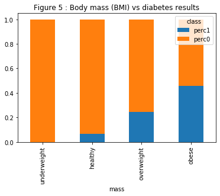

```python
#correlation between mass and class
corr_2_cols('mass', 'class').plot(stacked=True,kind="bar", title="Figure 5 : Body mass (BMI) vs diabetes results")
round(corr_2_cols('mass', 'class'),3)
```

From the above plot women having high BMI or belonging to obese category has more positive results compared to the rest.

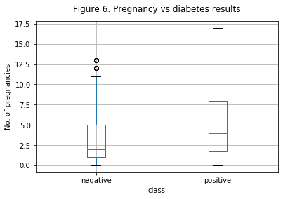

```python
# Boxplot  pregnancy and class
import matplotlib.pyplot as plt
diabetes_df.boxplot(column='preg',by='class')
plt.title("")
plt.suptitle("Figure 6: Pregnancy vs diabetes results")
plt.xlabel("class")
plt.ylabel("No. of pregnancies")
plt.show()
```

From the above plot people with more number of pregnancies can increase the chances of testing positive for diabetes.